# Basic Inferential Data Analysis on ToothGrowth

### Please refer to the Appendix for the code

### Summary of the dataset: ToothGrowth.

This dataset shows Effect of Vitamin c on Tooth Growth in Guinea Pigs. The response is the length of odontoblasts (cells responsible for tooth growth) in 60 guinea pigs. Each animal received one of three dose levels of vitamin C (0.5, 1, and 2 mg/day) by one of two delivery methods, (orange juice or ascorbic acid (a form of vitamin C and coded as VC).

A data frame with 60 observations on 3 variables.

1. The first variable Tooth length (‘len’) is numeric
2. The second variable Supplement type (supp) is a factor variable with levels (VC or OJ).
3. The third variable Dose(dose) is numeric and shows the Dose in milligrams/day

```r
summary(ToothGrowth)
```

```
##       len        supp         dose
##  Min.   : 4.20   OJ:30   Min.   :0.500
##  1st Qu.:13.07   VC:30   1st Qu.:0.500
##  Median :19.25           Median :1.000
##  Mean   :18.81           Mean   :1.167
##  3rd Qu.:25.27           3rd Qu.:2.000
##  Max.   :33.90           Max.   :2.000
```

### Basic Exploratory Data Analysis

The plot below shows the effect of the dosage of supplement on the Tooth Lengh.

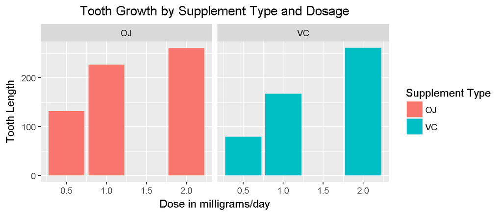

It appears that there is a direct relationship in the increase in Tooth Length to the Dosage of supplement. But we are unable to state which Supplement Type (OJ or VC) cause more tooth growth.

The plot below shows the effect of the dosage of type of supplement on the Tooth Lengh.

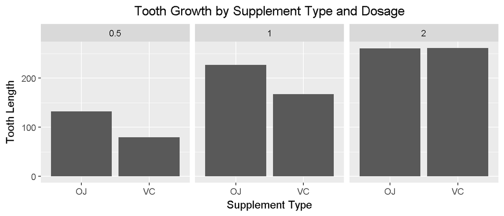

In this plot we observe that OJ supplement leads to better teeth growth for dosage quantities of 0.5 and 1, but is slightly lower than VC supplement for dosage quantity of 2. Hence we cannot completely sure if the supplement type is the cause for difference in tooth length.

#### Hypothesis tests to compare tooth growth by supplement type (OJ nd VC).

We will try to find out if the observed difference tooth length between the guinea pigs who received OJ or VC is statistically different than zero. We will use a t.test to determine if there is a difference in the teeth length based on the supplement type. We will run the t.test based on supplement and check if the p-value > 0.05 and if the confidence interval includes 0.

```r
t <- t.test(ToothGrowth$len[ToothGrowth$supp=="OJ"], ToothGrowth$len[ToothGrowth$supp=="VC"], paired = FALSE, var.equal = FALSE)
t
```

```
##
##  Welch Two Sample t-test
##
## data:  ToothGrowth$len[ToothGrowth$supp == "OJ"] and ToothGrowth$len[ToothGrowth$supp == "VC"]
## t = 1.9153, df = 55.309, p-value = 0.06063
## alternative hypothesis: true difference in means is not equal to 0
## 95 percent confidence interval:
##  -0.1710156  7.5710156
## sample estimates:
## mean of x mean of y
##  20.66333  16.96333
```

**We observe that the p-value using the above test is 0.06063 and Confidence Interval(-0.1710156 7.5710156), which includes 0. Hence we cannot believe that there is strong evidence to prove that observed difference tooth length between the guinea pigs who received OJ or VC is statistically different than zero.**

#### Hypothesis tests to compare tooth growth by dosage level.

Testing between dosage levels 1 and 0.5 milligrams/day

```r
t_1_0.5 <- t.test(ToothGrowth$len[ToothGrowth$dose==1], ToothGrowth$len[ToothGrowth$dose==0.5], paired = FALSE, var.equal = TRUE)
t_1_0.5
```

```
##
##  Two Sample t-test
##
## data:  ToothGrowth$len[ToothGrowth$dose == 1] and ToothGrowth$len[ToothGrowth$dose == 0.5]
## t = 6.4766, df = 38, p-value = 1.266e-07
## alternative hypothesis: true difference in means is not equal to 0
## 95 percent confidence interval:
##   6.276252 11.983748
## sample estimates:
## mean of x mean of y
##    19.735    10.605
```

Testing between dosage levels 2 and 1 milligrams/day

```r
t_2_1 <- t.test(ToothGrowth$len[ToothGrowth$dose==2], ToothGrowth$len[ToothGrowth$dose==1], paired = FALSE, var.equal = TRUE)
t_2_1
```

```
##
##  Two Sample t-test
##
## data:  ToothGrowth$len[ToothGrowth$dose == 2] and ToothGrowth$len[ToothGrowth$dose == 1]
## t = 4.9005, df = 38, p-value = 1.811e-05
## alternative hypothesis: true difference in means is not equal to 0
## 95 percent confidence interval:
##  3.735613 8.994387
## sample estimates:
## mean of x mean of y
##    26.100    19.735
```

Testing between dosage levels 2 and 0.5 milligrams/day

```r
t_2_0.5 <- t.test(ToothGrowth$len[ToothGrowth$dose==2], ToothGrowth$len[ToothGrowth$dose==0.5], paired = FALSE, var.equal = TRUE)
t_2_0.5
```

```
##
##  Two Sample t-test
##
## data:  ToothGrowth$len[ToothGrowth$dose == 2] and ToothGrowth$len[ToothGrowth$dose == 0.5]
## t = 11.799, df = 38, p-value = 2.838e-14
## alternative hypothesis: true difference in means is not equal to 0
## 95 percent confidence interval:
##  12.83648 18.15352
## sample estimates:
## mean of x mean of y
##    26.100    10.605
```

**Based on three results above, the p-value for all three combinations is lower than the significance level 0.05. Hence we can say that difference tooth length between the guinea pigs who received different dosage levels of supplement is statistically different than zero. Or that there is direct relation between the tooth growth and dosage levels received.**

#### Assumptions for the conclusions

We have assumed that the guinea pigs were randomly assigned to one of the groups that received the supplement type(OJ and VC) and that they were sampled from a nearly normal population.

#### Appendix

```r
library(datasets)
library(ggplot2)
datasets::ToothGrowth
ToothGrowth <- data.frame(datasets::ToothGrowth)
summary(ToothGrowth)
ggplot(data=ToothGrowth,aes(x=dose,y=len, fill=supp))  + geom_bar(stat = "identity") +
  facet_grid(.~supp) + xlab("Dose in milligrams/day") + ylab("Tooth Length") +
  guides(fill=guide_legend(title="Supplement Type")) +
  ggtitle("Tooth Growth by Supplement Type and Dosage") + theme(plot.title = element_text(hjust = 0.5))

ggplot(data=ToothGrowth,aes(x=supp,y=len))  + geom_bar(stat = "identity") +
  facet_grid(.~dose) + xlab("Supplement Type") + ylab("Tooth Length") +
  ggtitle("Tooth Growth by Supplement Type and Dosage") +
  theme(plot.title = element_text(hjust = 0.5))

t <- t.test(ToothGrowth$len[ToothGrowth$supp=="OJ"], ToothGrowth$len[ToothGrowth$supp=="VC"], paired = FALSE, var.equal = FALSE)
t_1_0.5 <- t.test(ToothGrowth$len[ToothGrowth$dose==1], ToothGrowth$len[ToothGrowth$dose==0.5], paired = FALSE, var.equal = TRUE)
t_1_0.5
t_2_1 <- t.test(ToothGrowth$len[ToothGrowth$dose==2], ToothGrowth$len[ToothGrowth$dose==1], paired = FALSE, var.equal = TRUE)
t_2_1
t_2_0.5 <- t.test(ToothGrowth$len[ToothGrowth$dose==2], ToothGrowth$len[ToothGrowth$dose==0.5], paired = FALSE, var.equal = TRUE)
t_2_0.5
```